# ML course project - PML movement prediction

Tan Vu

2024-05-15

## A. Sypnosis

This project aims to establish a machine learning model in order to predict the manner in which we do barbell lift exercise. The predictors to be used are the data obtained by accelerometers on the belt, forearm, arm and dumbell. The process can be briefed in to below steps:

- Using the raw data provided by the project assignment, first I remove variables that are not fully available across all observations.
- Next comes the exploratory analysis to identify the association between the available set of variable and the label (classe variable). This analysis is premise to shortlist the features for my machine learning model.
- Next comes the machine learning model buildup. Here I use cross validation to validate model performance. Random Forest is the better model, thus my chosen model for this assignment.

## B. Pre-processing & exploratory analysis

### 1. Loading data

```r
trainurl <- "https://d396qusza40orc.cloudfront.net/predmachlearn/pml-training.csv"
testurl <- "https://d396qusza40orc.cloudfront.net/predmachlearn/pml-testing.csv"
download.file(trainurl,destfile = "pmlTrain.csv",method = "curl")
download.file(testurl,destfile = "pmlTest.csv",method = "curl")
pmlTrain <- read.csv("./pmlTrain.csv",na.strings = "NA")
pmlTest <- read.csv("./pmlTest.csv",na.strings = "NA")

library(caret)
library(ggplot2)
library(dplyr)
library(purrr)
library(tidyr)
library(broom)
library(randomForest)

set.seed(1611)
```

### 2. Exploratory analysis

```r
# I'm hiding the results here since it's long & you should be familiar with it too

dim(pmlTrain)
str(pmlTrain)
head(pmlTrain, n = 10)
```

First quick check reveals a bunch of NA observations, so let’s see how many NA values for each column

```r
count_missing <- function(x){
    sum(is.na(x) | x == "")
}
missing_counts <- sapply(pmlTrain,count_missing)
missing_counts
```

[output not shown]

Glancing at the test dataset I found those bunch of columns with missing values also, & for all observations. My guess is those column between train & test sets are the same. Let’s check it.

```r
missing_counts_test <- sapply(pmlTest,count_missing)
missing_counts_test
```

```
##                        X                user_name     raw_timestamp_part_1
##                        0                        0                        0
##     raw_timestamp_part_2           cvtd_timestamp               new_window
##                        0                        0                        0
##               num_window                roll_belt               pitch_belt
##                        0                        0                        0
##                 yaw_belt         total_accel_belt       kurtosis_roll_belt
##                        0                        0                       20
##      kurtosis_picth_belt        kurtosis_yaw_belt       skewness_roll_belt
##                       20                       20                       20
##     skewness_roll_belt.1        skewness_yaw_belt            max_roll_belt
##                       20                       20                       20
##           max_picth_belt             max_yaw_belt            min_roll_belt
##                       20                       20                       20
##           min_pitch_belt             min_yaw_belt      amplitude_roll_belt
##                       20                       20                       20
##     amplitude_pitch_belt       amplitude_yaw_belt     var_total_accel_belt
##                       20                       20                       20
##            avg_roll_belt         stddev_roll_belt            var_roll_belt
##                       20                       20                       20
##           avg_pitch_belt        stddev_pitch_belt           var_pitch_belt
##                       20                       20                       20
##             avg_yaw_belt          stddev_yaw_belt             var_yaw_belt
##                       20                       20                       20
##             gyros_belt_x             gyros_belt_y             gyros_belt_z
##                        0                        0                        0
##             accel_belt_x             accel_belt_y             accel_belt_z
##                        0                        0                        0
##            magnet_belt_x            magnet_belt_y            magnet_belt_z
##                        0                        0                        0
##                 roll_arm                pitch_arm                  yaw_arm
##                        0                        0                        0
##          total_accel_arm            var_accel_arm             avg_roll_arm
##                        0                       20                       20
##          stddev_roll_arm             var_roll_arm            avg_pitch_arm
##                       20                       20                       20
##         stddev_pitch_arm            var_pitch_arm              avg_yaw_arm
##                       20                       20                       20
##           stddev_yaw_arm              var_yaw_arm              gyros_arm_x
##                       20                       20                        0
```

[output cut: 53 more lines]

```
##                       20                        0                       20
##         avg_roll_forearm      stddev_roll_forearm         var_roll_forearm
##                       20                       20                       20
##        avg_pitch_forearm     stddev_pitch_forearm        var_pitch_forearm
##                       20                       20                       20
##          avg_yaw_forearm       stddev_yaw_forearm          var_yaw_forearm
##                       20                       20                       20
##          gyros_forearm_x          gyros_forearm_y          gyros_forearm_z
##                        0                        0                        0
##          accel_forearm_x          accel_forearm_y          accel_forearm_z
##                        0                        0                        0
##         magnet_forearm_x         magnet_forearm_y         magnet_forearm_z
##                        0                        0                        0
##               problem_id
##                        0
```

So those columns with missing values are the same between train & test dataset. Therefore it’s safe to remove thosoe columns fromm train dataset

```r
pmlTrain1 <- pmlTrain[,missing_counts == 0]
dim(pmlTrain1)
```

```
## [1] 19622    60
```

Next let’s see the observation number of each classe within the training dataset

```r
table(pmlTrain1$classe)
```

```
##
##    A    B    C    D    E
## 5580 3797 3422 3216 3607
```

The observation amount here should be fine to split the training set into a training set & a validation set.

```r
# Also here I transform classe variable into factors
pmlTrain1$classe <- as.factor(pmlTrain1$classe)

# Group up those variables that I'm quite confident have no impact on classe, i.e no chance of being a feature. I'm not so sure about "num_window" variable, seems not a metric measured by a tracking device, I retain it in remaining variables to be filtered more since it's numerical.

nonFeatures <- c("X","user_name","raw_timestamp_part_1","raw_timestamp_part_2","cvtd_timestamp","new_window")
```

Next understanding that our label (classe) are factors, while remaining variables are numerical or integer, I try plotting the average values for those variables by classe. & since absolute values of remaining variables (except the label) are quite different, I need to standardize their values before putting up a plot.

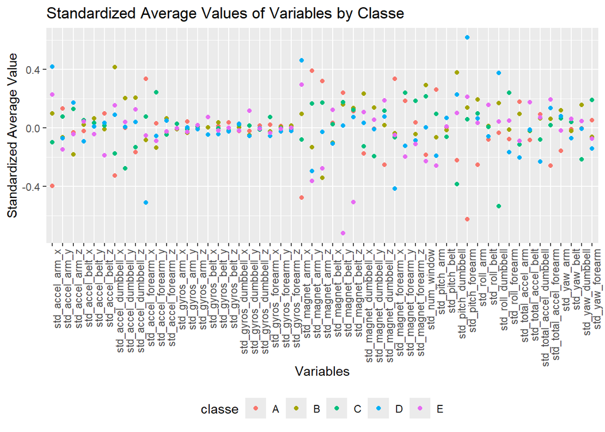

```r
pmlTrain1_filtered <- pmlTrain1 %>%
    select(-nonFeatures)

pmlTrain1_standardized <- pmlTrain1_filtered %>%
    mutate(across(-classe, ~ (.- mean(.)) / sd(.), .names = "std_{.col}"))

pmlTrain1_long <- pmlTrain1_standardized %>%
    pivot_longer(cols = starts_with("std_"), names_to = "variable", values_to = "value")

pmlTrain1_summary <- pmlTrain1_long %>%
    group_by(variable, classe) %>%
    summarize(mean_value = mean(value, na.rm = TRUE)) %>%
    ungroup()

ggplot(pmlTrain1_summary, aes(x = variable, y = mean_value, color = classe)) +
    geom_point() +
    labs(x = "Variables", y = "Standardized Average Value", title = "Standardized Average Values of Variables by Classe") +
    theme(axis.text.x = element_text(angle = 90, hjust = 1), legend.position = "bottom")
```

I can observe from the plot that lots of variables have the average standardized values based on classe separated from each other, & different from 0, suggesting those variables are associated with classe. Example include: accel_arm_x, accel_dumbell_x, magnet_arm_x, etc.

Meanwhile, other variables have the average standardized values based on classe clustered together & close to 0, suggesting those variables are less useful in predicting classe.

## C. Building up prediction model

### 1. Shortlist the features

Based on the observation in exploratory analysis, I move on to see explore which features should be selected in the machine learning model, based on their impact on classe statistically.

```r
# Function to perform ANOVA and return the p-value
anova_pvalue <- function(feature) {
    anova_result <- aov(value ~ classe, data = feature)
    p_value <- summary(anova_result)[[1]][["Pr(>F)"]][1]
    return(p_value)
}

# Reshape data to long format for ANOVA
trainLong <- pmlTrain1_filtered %>%
    pivot_longer(cols = -classe, names_to = "variable", values_to = "value")

# Group by variable and apply ANOVA
anova_results <- trainLong %>%
    group_by(variable) %>%
    nest() %>%
    mutate(p_value = map_dbl(data, anova_pvalue))

# Filter results to keep only significant features (e.g., p-value < 0.05)
significant_features <- anova_results %>%
  filter(p_value < 0.05)
```

So I’ve filtered out those 47 variables that should have significant impact on classe. Next is to establish the training dataset consisting of such 47 variables

```r
# Extract the names of the significant variables
significant_vars <- significant_features$variable

# Create a new dataset with only the significant variables and the label
pmlTrain1_final <- pmlTrain1_filtered %>%
    select(classe, all_of(significant_vars))
```

### 2. Cross-validation: split the data

For cross-validation purpose, I further split the training set into a training set & a validation set

```r
inTrain <- createDataPartition(pmlTrain1_final$classe,p = 0.7, list = FALSE)

trainFinal <- pmlTrain1_final[inTrain,]
valFinal <- pmlTrain1_final[-inTrain,]
```

### 3. Prediction model buildup

Here using cross validation, I’m trying to see which prediction model provides the best prediction result

```r
train_control <- trainControl(method = "cv", number = 3)
```

#### a. Mutinom to begin with

```r
logModel <- train(
  classe ~ .,
  data = trainFinal,
  method = "multinom",
  trControl = train_control
)
```

Let’s see how good this model is when predicting with the validation dataset

```r
logValPred <- predict(logModel,newdata = valFinal)
logCM <- confusionMatrix(logValPred,valFinal$classe)
print(logCM)
```

```
## Confusion Matrix and Statistics
##
##           Reference
## Prediction    A    B    C    D    E
##          A 1444  159  140   60   75
##          B   43  597   68   42  122
##          C   77  156  647  127  104
##          D   89  105  122  691  149
##          E   21  122   49   44  632
##
## Overall Statistics
##
##                Accuracy : 0.6816
##                  95% CI : (0.6695, 0.6935)
##     No Information Rate : 0.2845
##     P-Value [Acc > NIR] : < 2.2e-16
##
##                   Kappa : 0.5961
##
##  Mcnemar's Test P-Value : < 2.2e-16
##
## Statistics by Class:
##
##                      Class: A Class: B Class: C Class: D Class: E
## Sensitivity            0.8626   0.5241   0.6306   0.7168   0.5841
## Specificity            0.8969   0.9421   0.9045   0.9055   0.9509
## Pos Pred Value         0.7689   0.6846   0.5824   0.5978   0.7281
## Neg Pred Value         0.9426   0.8919   0.9206   0.9423   0.9103
## Prevalence             0.2845   0.1935   0.1743   0.1638   0.1839
## Detection Rate         0.2454   0.1014   0.1099   0.1174   0.1074
## Detection Prevalence   0.3191   0.1482   0.1888   0.1964   0.1475
## Balanced Accuracy      0.8798   0.7331   0.7676   0.8112   0.7675
```

Accuracy of 68.16% is not so impressive. Probably the type of our dataset (categorical label & multiple other numerical predictors) is not suitable for logistic regression.

#### b. Next is Random Forest

```r
rfModel <- train(classe ~ .,data = trainFinal,method = "rf",trControl = train_control,importance = TRUE)
```

Again I check how this works with the validation dataset

```r
rfValPred <- predict(rfModel,newdata = valFinal)
rfCM <- confusionMatrix(rfValPred,valFinal$classe)
print(rfCM)
```

```
## Confusion Matrix and Statistics
##
##           Reference
## Prediction    A    B    C    D    E
##          A 1674    4    0    0    0
##          B    0 1134    2    0    0
##          C    0    1 1024    2    0
##          D    0    0    0  962    2
##          E    0    0    0    0 1080
##
## Overall Statistics
##
##                Accuracy : 0.9981
##                  95% CI : (0.9967, 0.9991)
##     No Information Rate : 0.2845
##     P-Value [Acc > NIR] : < 2.2e-16
##
##                   Kappa : 0.9976
##
##  Mcnemar's Test P-Value : NA
##
## Statistics by Class:
##
##                      Class: A Class: B Class: C Class: D Class: E
## Sensitivity            1.0000   0.9956   0.9981   0.9979   0.9982
## Specificity            0.9991   0.9996   0.9994   0.9996   1.0000
## Pos Pred Value         0.9976   0.9982   0.9971   0.9979   1.0000
## Neg Pred Value         1.0000   0.9989   0.9996   0.9996   0.9996
## Prevalence             0.2845   0.1935   0.1743   0.1638   0.1839
## Detection Rate         0.2845   0.1927   0.1740   0.1635   0.1835
## Detection Prevalence   0.2851   0.1930   0.1745   0.1638   0.1835
## Balanced Accuracy      0.9995   0.9976   0.9987   0.9988   0.9991
```

## D. Prediction

I’ll use Random Forest model to predict with the test dataset

```r
testFinal <- pmlTest %>%
    select(all_of(significant_vars))
rfPred <- predict(rfModel,newdata = testFinal)
print(rfPred)
```

```
##  [1] B A B A A E D B A A B C B A E E A B B B
## Levels: A B C D E
```